# 2 Hands On: Data Quality and Pre-Processing

**1. Assessing Data Quality**

*Load the carInsurance data set about the insurance risk rating of cars based on several characteristics of each car.*

1. Check if there are any missing values.

```r
load("C:/Proyectos ML/Mineria/Hands_On_2/data/carInsurance.Rdata")
data <- as.data.frame(carIns)
has_missing_values <- anyNA(data)
print(has_missing_values)
```

```
## [1] TRUE
```

2. Count the number of cases that have, at least, one missing value.

```r
library(dplyr)
data <- as.data.frame(carIns)
filas<- nrow(data)
print(sprintf("Número de filas totales %d",filas))
```

```
## [1] "Número de filas totales 205"
```

```r
filtered_data <- data %>% filter(complete.cases(.))
filas_completas <-nrow(filtered_data)
print(sprintf("Número de filas completas %d",filas_completas))
```

```
## [1] "Número de filas completas 159"
```

3. Create a new data set by removing all the cases that have missing values.

```r
library(dplyr)

df <- as.data.frame(carIns)
filtrar <- df[complete.cases(df) ==  TRUE,]
print(filtrar)
```

```
##     symb normLoss          make fuelType aspiration nDoors   bodyStyle
## 4      2      164          audi      gas        std   four       sedan
## 5      2      164          audi      gas        std   four       sedan
## 7      1      158          audi      gas        std   four       sedan
## 9      1      158          audi      gas      turbo   four       sedan
## 11     2      192           bmw      gas        std    two       sedan
## 12     0      192           bmw      gas        std   four       sedan
## 13     0      188           bmw      gas        std    two       sedan
## 14     0      188           bmw      gas        std   four       sedan
## 19     2      121     chevrolet      gas        std    two   hatchback
## 20     1       98     chevrolet      gas        std    two   hatchback
## 21     0       81     chevrolet      gas        std   four       sedan
## 22     1      118         dodge      gas        std    two   hatchback
## 23     1      118         dodge      gas        std    two   hatchback
## 24     1      118         dodge      gas      turbo    two   hatchback
```

[output cut: 625 more lines]

4. Create a new data set by imputing all the missing values with 0.

```r
#install.packages("tidyimpute")
library(tidyimpute)
datos_sin_cero<- carIns %>%na.omit()
# Cree un nuevo conjunto de datos con valores faltantes imputados como 0
imputed_data <- impute(datos_sin_cero, method = "fixed", fixed_value = 0)

# View the imputed dataset
head(imputed_data)
```

| symb | normLoss | make | fuelType | aspiration | nDoors | bodyStyle | driveWheels | engineLocation | wheelBase | length | width | height | curbWeight | engineType | nrCylinds | engineSize | fuelSystem | bore | stroke | compressionRatio | horsePower | peakRpm | cityMpg | highwayMpg | price |
| --- | --- | --- | --- | --- | --- | --- | --- | --- | --- | --- | --- | --- | --- | --- | --- | --- | --- | --- | --- | --- | --- | --- | --- | --- | --- |
| 2 | 164 | audi | gas | std | four | sedan | fwd | front | 99.8 | 176.6 | 66.2 | 54.3 | 2337 | ohc | four | 109 | mpfi | 3.19 | 3.4 | 10.0 | 102 | 5500 | 24 | 30 | 13950 |
| 2 | 164 | audi | gas | std | four | sedan | 4wd | front | 99.4 | 176.6 | 66.4 | 54.3 | 2824 | ohc | five | 136 | mpfi | 3.19 | 3.4 | 8.0 | 115 | 5500 | 18 | 22 | 17450 |
| 1 | 158 | audi | gas | std | four | sedan | fwd | front | 105.8 | 192.7 | 71.4 | 55.7 | 2844 | ohc | five | 136 | mpfi | 3.19 | 3.4 | 8.5 | 110 | 5500 | 19 | 25 | 17710 |
| 1 | 158 | audi | gas | turbo | four | sedan | fwd | front | 105.8 | 192.7 | 71.4 | 55.9 | 3086 | ohc | five | 131 | mpfi | 3.13 | 3.4 | 8.3 | 140 | 5500 | 17 | 20 | 23875 |
| 2 | 192 | bmw | gas | std | two | sedan | rwd | front | 101.2 | 176.8 | 64.8 | 54.3 | 2395 | ohc | four | 108 | mpfi | 3.50 | 2.8 | 8.8 | 101 | 5800 | 23 | 29 | 16430 |
| 0 | 192 | bmw | gas | std | four | sedan | rwd | front | 101.2 | 176.8 | 64.8 | 54.3 | 2395 | ohc | four | 108 | mpfi | 3.50 | 2.8 | 8.8 | 101 | 5800 | 23 | 29 | 16925 |

5. Create a new data set by imputing the mean in all the columns which have double type values

```r
library(dplyr)
datos<- carIns%>%filter(complete.cases(.))
# Create a new dataset by imputing the mean in columns with double type values
imputed_data <-  datos %>%mutate_if(is.double, ~ ifelse(is.na(.), mean(., na.rm = TRUE), .))
head(imputed_data)
```

| symb | normLoss | make | fuelType | aspiration | nDoors | bodyStyle | driveWheels | engineLocation | wheelBase | length | width | height | curbWeight | engineType | nrCylinds | engineSize | fuelSystem | bore | stroke | compressionRatio | horsePower | peakRpm | cityMpg | highwayMpg | price |
| --- | --- | --- | --- | --- | --- | --- | --- | --- | --- | --- | --- | --- | --- | --- | --- | --- | --- | --- | --- | --- | --- | --- | --- | --- | --- |
| 2 | 164 | audi | gas | std | four | sedan | fwd | front | 99.8 | 176.6 | 66.2 | 54.3 | 2337 | ohc | four | 109 | mpfi | 3.19 | 3.4 | 10.0 | 102 | 5500 | 24 | 30 | 13950 |
| 2 | 164 | audi | gas | std | four | sedan | 4wd | front | 99.4 | 176.6 | 66.4 | 54.3 | 2824 | ohc | five | 136 | mpfi | 3.19 | 3.4 | 8.0 | 115 | 5500 | 18 | 22 | 17450 |
| 1 | 158 | audi | gas | std | four | sedan | fwd | front | 105.8 | 192.7 | 71.4 | 55.7 | 2844 | ohc | five | 136 | mpfi | 3.19 | 3.4 | 8.5 | 110 | 5500 | 19 | 25 | 17710 |
| 1 | 158 | audi | gas | turbo | four | sedan | fwd | front | 105.8 | 192.7 | 71.4 | 55.9 | 3086 | ohc | five | 131 | mpfi | 3.13 | 3.4 | 8.3 | 140 | 5500 | 17 | 20 | 23875 |
| 2 | 192 | bmw | gas | std | two | sedan | rwd | front | 101.2 | 176.8 | 64.8 | 54.3 | 2395 | ohc | four | 108 | mpfi | 3.50 | 2.8 | 8.8 | 101 | 5800 | 23 | 29 | 16430 |
| 0 | 192 | bmw | gas | std | four | sedan | rwd | front | 101.2 | 176.8 | 64.8 | 54.3 | 2395 | ohc | four | 108 | mpfi | 3.50 | 2.8 | 8.8 | 101 | 5800 | 23 | 29 | 16925 |

6. Create a new data set by imputing the mode in all the columns which have integer type values.

```r
# Identify names columns with integer type values
eliminar_na <- carIns %>%filter(complete.cases(.))
integer_columns <- sapply(eliminar_na, is.integer)
seleccionar_columnas <- names(integer_columns[integer_columns])
print(seleccionar_columnas)
```

```
## [1] "symb"       "normLoss"   "curbWeight" "engineSize" "horsePower"
## [6] "peakRpm"    "cityMpg"    "highwayMpg" "price"
```

```r
# Funcion para calcular la moda de un vector
Mode <- function(x) {
  ux <- unique(x)
  ux[which.max(tabulate(match(x, ux)))]
}
# Calcular la moda para cada entero en la columna
modes <- sapply(eliminar_na[, integer_columns], Mode)

# Imprimir el nombre de la columna con su respectiva moda
for (i in 1:length(modes)) {
  print(paste("Column:", names(modes)[i], "Mode:", modes[i]))
}
```

```
## [1] "Column: symb Mode: 0"
## [1] "Column: normLoss Mode: 161"
## [1] "Column: curbWeight Mode: 1989"
## [1] "Column: engineSize Mode: 92"
## [1] "Column: horsePower Mode: 68"
## [1] "Column: peakRpm Mode: 4800"
## [1] "Column: cityMpg Mode: 31"
## [1] "Column: highwayMpg Mode: 38"
## [1] "Column: price Mode: 5572"
```

7. Create a new data set by imputing the most frequent value to the column nDoors

```r
# Load the required packages
library(dplyr)

# Load the carInsurance dataset
eliminar_na <- carIns%>%na.omit()

# Define the Mode function to calculate the mode of a vector
Mode <- function(x) {
  ux <- unique(x)
  ux[which.max(tabulate(match(x, ux)))]
}

# Create a new data set by imputing the most frequent value to the column "nDoors"
new_carInsurance <- carIns %>%
  mutate(nDoors = ifelse(is.na(nDoors), Mode(nDoors), nDoors))

# Print the new data set
print(new_carInsurance)
```

```
## # A tibble: 205 × 26
##     symb normLoss make        fuelType aspiration nDoors bodyStyle   driveWheels
##    <int>    <int> <fct>       <fct>    <fct>       <int> <fct>       <fct>
##  1     3       NA alfa-romero gas      std             2 convertible rwd
##  2     3       NA alfa-romero gas      std             2 convertible rwd
##  3     1       NA alfa-romero gas      std             2 hatchback   rwd
##  4     2      164 audi        gas      std             1 sedan       fwd
##  5     2      164 audi        gas      std             1 sedan       4wd
##  6     2       NA audi        gas      std             2 sedan       fwd
##  7     1      158 audi        gas      std             1 sedan       fwd
##  8     1       NA audi        gas      std             1 wagon       fwd
##  9     1      158 audi        gas      turbo           1 sedan       fwd
## 10     0       NA audi        gas      turbo           2 hatchback   4wd
## # ℹ 195 more rows
## # ℹ 18 more variables: engineLocation <fct>, wheelBase <dbl>, length <dbl>,
## #   width <dbl>, height <dbl>, curbWeight <int>, engineType <fct>,
## #   nrCylinds <fct>, engineSize <int>, fuelSystem <fct>, bore <dbl>,
## #   stroke <dbl>, compressionRatio <dbl>, horsePower <int>, peakRpm <int>,
## #   cityMpg <int>, highwayMpg <int>, price <int>
```

8. Combine the three last imputations to obtain a final dataset. Are there any duplicated cases?

```r
# Load the required packages
library(dplyr)

# Define the Mode function to calculate the mode of a vector
Mode <- function(x) {
  ux <- unique(x)
  ux[which.max(tabulate(match(x, ux)))]
}

# Impute missing values in columns with integer type using mode
carInsurance_imputed_mode <- carIns %>%
  mutate(across(where(is.integer), ~ ifelse(is.na(.), Mode(.), .)))

# Impute missing values in the "nDoors" column using the most frequent value
carInsurance_imputed_nDoors <- carInsurance_imputed_mode %>%
  mutate(nDoors = ifelse(is.na(nDoors), Mode(nDoors), nDoors))

# Convert the "nDoors" column to character type in both datasets
carInsurance_imputed_mode$nDoors <- as.character(carInsurance_imputed_mode$nDoors)
carInsurance_imputed_nDoors$nDoors <- as.character(carInsurance_imputed_nDoors$nDoors)

# Combine the imputed datasets to obtain a final dataset
final_carInsurance <- bind_rows(carInsurance_imputed_mode, carInsurance_imputed_nDoors)

# Check for duplicated cases
duplicated_cases <- final_carInsurance %>%
  distinct() %>%
  count() %>%
  filter(n > 1)

# Print the duplicated cases
print(duplicated_cases)
```

```
## # A tibble: 1 × 1
##       n
##   <int>
## 1   410
```

**2. Data Pre-Processing**

Leer the package dlookr. Use the same car insurance data set above and apply the following transformations to the price attribute. Be critical regarding the obtained results.

(a)Apply range-based normalization and z-score normalization.

```r
library(dplyr)

normalizar<-carIns %>%  mutate(
          # Aplica la normalizaciÃ³n basada en rangos
          precioNormRango = (price - min(price, na.rm = TRUE)) / (max(price, na.rm = TRUE) - min(price, na.rm = TRUE)), # Escala los valores de la columna de precio al rango [0,1]
          # Aplica la normalizaciÃ³n Z-score
          precioNormZscore = (price - mean(price, na.rm = TRUE)) / sd(price, na.rm = TRUE)
)
print(normalizar)
```

```
## # A tibble: 205 × 28
##     symb normLoss make        fuelType aspiration nDoors bodyStyle   driveWheels
##    <int>    <int> <fct>       <fct>    <fct>      <fct>  <fct>       <fct>
##  1     3       NA alfa-romero gas      std        two    convertible rwd
##  2     3       NA alfa-romero gas      std        two    convertible rwd
##  3     1       NA alfa-romero gas      std        two    hatchback   rwd
##  4     2      164 audi        gas      std        four   sedan       fwd
##  5     2      164 audi        gas      std        four   sedan       4wd
##  6     2       NA audi        gas      std        two    sedan       fwd
##  7     1      158 audi        gas      std        four   sedan       fwd
##  8     1       NA audi        gas      std        four   wagon       fwd
##  9     1      158 audi        gas      turbo      four   sedan       fwd
## 10     0       NA audi        gas      turbo      two    hatchback   4wd
## # ℹ 195 more rows
## # ℹ 20 more variables: engineLocation <fct>, wheelBase <dbl>, length <dbl>,
## #   width <dbl>, height <dbl>, curbWeight <int>, engineType <fct>,
## #   nrCylinds <fct>, engineSize <int>, fuelSystem <fct>, bore <dbl>,
## #   stroke <dbl>, compressionRatio <dbl>, horsePower <int>, peakRpm <int>,
## #   cityMpg <int>, highwayMpg <int>, price <int>, precioNormRango <dbl>,
## #   precioNormZscore <dbl>
```

2. Discretize it into 4 equal-frequency ranges an into 4 equal-width ranges.

```r
carIns2<-carIns %>%na.omit()

# Discretize price into 4 equal-frequency ranges
carIns2$price_freq <- cut(carIns2$price, breaks = quantile(carIns2$price, probs = seq(0, 1, by = 0.25), na.rm = TRUE), labels = FALSE, include.lowest = TRUE)

# Discretize price into 4 equal-width ranges
carIns2$price_width <- cut(carIns2$price, breaks = 4, labels = FALSE, include.lowest = TRUE)

# Print the transformed data set
print(carIns2)
```

```
## # A tibble: 159 × 28
##     symb normLoss make      fuelType aspiration nDoors bodyStyle driveWheels
##    <int>    <int> <fct>     <fct>    <fct>      <fct>  <fct>     <fct>
##  1     2      164 audi      gas      std        four   sedan     fwd
##  2     2      164 audi      gas      std        four   sedan     4wd
##  3     1      158 audi      gas      std        four   sedan     fwd
##  4     1      158 audi      gas      turbo      four   sedan     fwd
##  5     2      192 bmw       gas      std        two    sedan     rwd
##  6     0      192 bmw       gas      std        four   sedan     rwd
##  7     0      188 bmw       gas      std        two    sedan     rwd
##  8     0      188 bmw       gas      std        four   sedan     rwd
##  9     2      121 chevrolet gas      std        two    hatchback fwd
## 10     1       98 chevrolet gas      std        two    hatchback fwd
## # ℹ 149 more rows
## # ℹ 20 more variables: engineLocation <fct>, wheelBase <dbl>, length <dbl>,
## #   width <dbl>, height <dbl>, curbWeight <int>, engineType <fct>,
## #   nrCylinds <fct>, engineSize <int>, fuelSystem <fct>, bore <dbl>,
## #   stroke <dbl>, compressionRatio <dbl>, horsePower <int>, peakRpm <int>,
## #   cityMpg <int>, highwayMpg <int>, price <int>, price_freq <int>,
## #   price_width <int>
```

**3. With the seed 111019 obtain the following samples on the car insurance data set.**

1. A random sample of 60% of the cases, with replacement

```r
library(dplyr)
muestra_60 <- sample_frac(carIns, 0.6)
print(muestra_60)
```

```
## # A tibble: 123 × 26
##     symb normLoss make          fuelType aspiration nDoors bodyStyle driveWheels
##    <int>    <int> <fct>         <fct>    <fct>      <fct>  <fct>     <fct>
##  1    -1       95 volvo         gas      turbo      four   sedan     rwd
##  2     3       NA porsche       gas      std        two    hardtop   rwd
##  3    -1       NA mercedes-benz gas      std        four   sedan     rwd
##  4     0      188 bmw           gas      std        four   sedan     rwd
##  5     0       93 mercedes-benz diesel   turbo      two    hardtop   rwd
##  6     3      153 mitsubishi    gas      turbo      two    hatchback fwd
##  7     1      168 toyota        gas      std        two    sedan     rwd
##  8     0       78 honda         gas      std        four   wagon     fwd
##  9     1      104 mazda         gas      std        two    hatchback fwd
## 10     1       NA mercedes-benz gas      std        two    hardtop   rwd
## # ℹ 113 more rows
## # ℹ 18 more variables: engineLocation <fct>, wheelBase <dbl>, length <dbl>,
## #   width <dbl>, height <dbl>, curbWeight <int>, engineType <fct>,
## #   nrCylinds <fct>, engineSize <int>, fuelSystem <fct>, bore <dbl>,
## #   stroke <dbl>, compressionRatio <dbl>, horsePower <int>, peakRpm <int>,
## #   cityMpg <int>, highwayMpg <int>, price <int>
```

2. A stratified sample of 60% of the cases of cars, according to the fuelType attribute

```r
# Install and load the splitstackshape package
#install.packages("splitstackshape")
library(splitstackshape)
set.seed(111019)
strat_campo <- stratified(carIns, "fuelType", 0.6)

print(strat_campo)
```

```
##      symb normLoss          make fuelType aspiration nDoors bodyStyle
##   1:    1      103        nissan      gas        std   four     wagon
##   2:    1      101         honda      gas        std    two hatchback
##   3:    3       NA       porsche      gas        std    two   hardtop
##   4:    2       NA          audi      gas        std    two     sedan
##   5:    0       91        toyota      gas        std   four     sedan
##  ---
## 119:    0      161        peugot   diesel      turbo   four     sedan
## 120:   -1       93 mercedes-benz   diesel      turbo   four     wagon
## 121:   -1       65        toyota   diesel      turbo   four     sedan
## 122:    0       NA        peugot   diesel      turbo   four     wagon
## 123:    0       NA    volkswagen   diesel      turbo   four     sedan
##      driveWheels engineLocation wheelBase length width height curbWeight
##   1:         fwd          front      94.5  170.2  63.8   53.5       2037
##   2:         fwd          front      93.7  150.0  64.0   52.6       1940
```

[output cut: 33 more lines]

3. Use the table() function to inspect the distribution of values in each of the two samples above.

```r
load("C:/Proyectos ML/Mineria/Hands_On_2/carIns_final.Rdata")
data <- as.data.frame(carIns_final)
# Set the seed
# Set the seed
set.seed(111019)

# Obtain a random sample of 60% of the cases with replacement
muestra_data_1 <- sample_frac(data, 0.6, replace = TRUE)$fuelType

# Obtain a random sample of 40% of the cases with replacement
muestra_data_2 <- sample_frac(data, 0.4, replace = TRUE)$make

# Inspect the distribution of values in each sample
table_sample_1 <- table(muestra_data_1)
table_sample_2 <- table(muestra_data_2)

# View the distributions
cat("Combustible\n")
```

```
## Combustible
```

```r
print(table_sample_1)
```

```
## muestra_data_1
## diesel    gas
##      8    115
```

```r
cat("\nTipo auto\n")
```

```
##
## Tipo auto
```

```r
print(table_sample_2)
```

```
## muestra_data_2
##   alfa-romero          audi           bmw     chevrolet         dodge
##             1             4             1             0             4
##         honda         isuzu        jaguar         mazda mercedes-benz
##             2             4             1             3             2
##       mercury    mitsubishi        nissan        peugot      plymouth
##             1             4             8             8             8
##       porsche       renault          saab        subaru        toyota
##             3             0             2             4             7
##    volkswagen         volvo
##             6             9
```

**4. Load the package corrplot and select the numeric attributes of the car insurance data set.**

1. Using the function cor(), obtain the pearson correlation coefficient between each pair of variables.

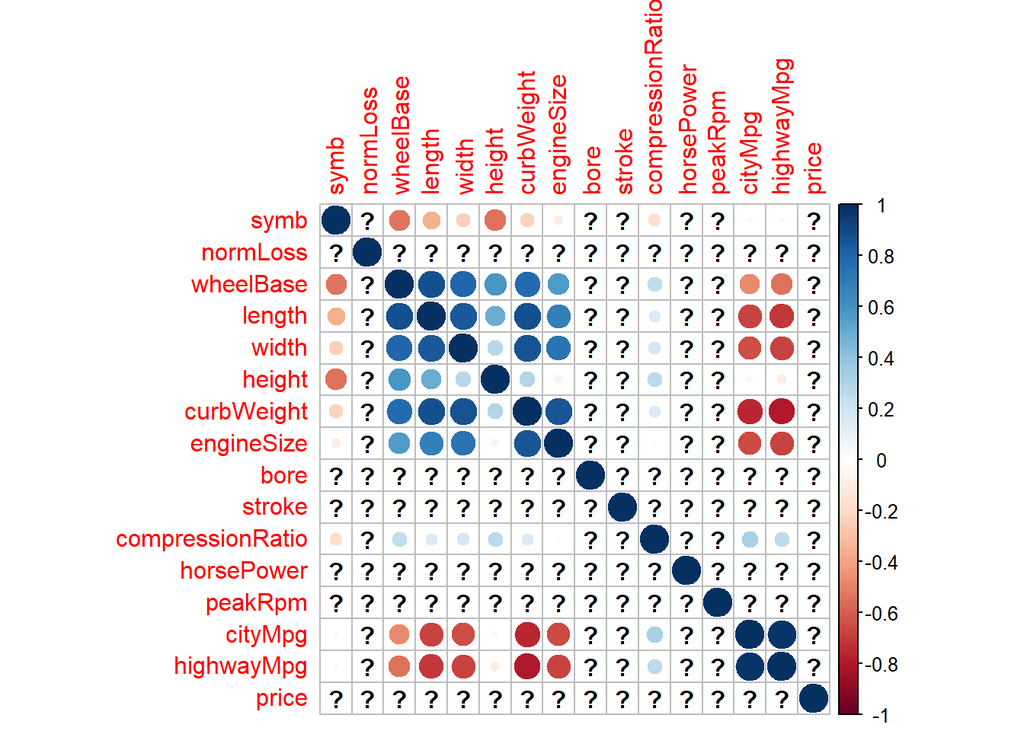

```r
#install.packages("corrplot")
library(corrplot)
numeric_data <- carIns[, sapply(carIns, is.numeric)]
cor_matrix <- cor(numeric_data)

corrplot(cor_matrix, method = "circle")
```

(b) Apply the function cor.mtest() to the previous result to calculate the p-values and confidence intervals of the correlation coefficient for each pair of variables.

```r
library(corrplot)
numeric_data <- carIns[, sapply(carIns, is.numeric)]

cor_matrix <- cor(numeric_data)

library(psych)
cor_test <- cor.mtest(numeric_data)


p_values <- cor_test$p

conf_intervals <- cor_test$uppCI

cat("\n p_values ")
```

```
##
##  p_values
```

```r
cat("\n ----------------------------------------------------------- \n")
print(p_values)
```

```
##                          symb     normLoss    wheelBase       length
## symb             0.000000e+00 3.432929e-13 2.255894e-16 1.409339e-07
## normLoss         3.432929e-13 0.000000e+00 3.439849e-01 7.679017e-01
## wheelBase        2.255894e-16 3.439849e-01 0.000000e+00 9.699227e-66
## length           1.409339e-07 7.679017e-01 9.699227e-66 0.000000e+00
## width            7.770414e-04 1.805700e-01 5.612752e-46 4.332386e-56
## height           5.531350e-17 7.428895e-09 1.437985e-20 7.731666e-14
## curbWeight       1.025874e-03 1.262266e-01 1.439877e-42 8.728146e-67
## engineSize       1.311313e-01 3.218897e-02 5.233096e-19 1.496334e-29
## bore             5.750916e-02 6.497992e-01 1.475771e-13 1.162914e-21
## stroke           8.994914e-01 4.096535e-01 2.201552e-02 6.640708e-02
## compressionRatio 1.043948e-02 9.039883e-02 3.039092e-04 2.329180e-02
## horsePower       3.098897e-01 1.204793e-04 2.540628e-07 8.505849e-18
## peakRpm          7.359080e-05 6.174988e-04 1.209679e-07 3.232254e-05
## cityMpg          6.101009e-01 8.314261e-04 1.103347e-12 3.595529e-28
## highwayMpg       6.222950e-01 6.748692e-03 3.420917e-17 4.428948e-32
## price            2.449149e-01 9.045759e-03 8.076488e-20 8.016477e-30
##                         width       height   curbWeight   engineSize
## symb             7.770414e-04 5.531350e-17 1.025874e-03 1.311313e-01
## normLoss         1.805700e-01 7.428895e-09 1.262266e-01 3.218897e-02
## wheelBase        5.612752e-46 1.437985e-20 1.439877e-42 5.233096e-19
## length           4.332386e-56 7.731666e-14 8.728146e-67 1.496334e-29
## width            0.000000e+00 5.031446e-05 2.460481e-63 3.685904e-36
## height           5.031446e-05 0.000000e+00 1.688129e-05 3.387566e-01
## curbWeight       2.460481e-63 1.688129e-05 0.000000e+00 1.404581e-58
## engineSize       3.685904e-36 3.387566e-01 1.404581e-58 0.000000e+00
## bore             6.240938e-18 1.234844e-02 2.013256e-25 1.455497e-20
## stroke           9.331725e-03 4.215601e-01 1.651667e-02 3.243224e-03
## compressionRatio 9.348405e-03 1.549235e-04 3.027941e-02 6.800779e-01
## horsePower       5.048681e-25 1.158388e-01 4.321574e-38 1.236008e-48
## peakRpm          1.614542e-03 2.745139e-06 1.228169e-04 4.359121e-04
## cityMpg          2.807249e-25 4.885825e-01 1.929250e-39 2.298962e-26
## highwayMpg       7.321537e-29 1.254830e-01 2.007127e-46 6.864987e-29
## price            9.200336e-38 5.514627e-02 2.189577e-53 9.265492e-64
##                          bore      stroke compressionRatio   horsePower
## symb             5.750916e-02 0.899491367     1.043948e-02 3.098897e-01
## normLoss         6.497992e-01 0.409653480     9.039883e-02 1.204793e-04
## wheelBase        1.475771e-13 0.022015524     3.039092e-04 2.540628e-07
## length           1.162914e-21 0.066407079     2.329180e-02 8.505849e-18
## width            6.240938e-18 0.009331725     9.348405e-03 5.048681e-25
```

[output cut: 13 more lines]

```
## normLoss         6.174988e-04  8.314261e-04  6.748692e-03 9.045759e-03
## wheelBase        1.209679e-07  1.103347e-12  3.420917e-17 8.076488e-20
## length           3.232254e-05  3.595529e-28  4.428948e-32 8.016477e-30
## width            1.614542e-03  2.807249e-25  7.321537e-29 9.200336e-38
## height           2.745139e-06  4.885825e-01  1.254830e-01 5.514627e-02
## curbWeight       1.228169e-04  1.929250e-39  2.007127e-46 2.189577e-53
## engineSize       4.359121e-04  2.298962e-26  6.864987e-29 9.265492e-64
## bore             1.620994e-04  1.328843e-20  1.331729e-20 1.567358e-16
## stroke           3.156381e-01  5.453234e-01  5.302181e-01 2.501958e-01
## compressionRatio 7.737735e-11  2.034939e-06  1.215757e-04 3.158110e-01
## horsePower       6.252497e-02  3.486622e-47  3.062649e-41 1.189128e-47
## peakRpm          0.000000e+00  1.059931e-01  4.419900e-01 1.531182e-01
## cityMpg          1.059931e-01  0.000000e+00 1.248739e-128 2.321132e-29
## highwayMpg       4.419900e-01 1.248739e-128  0.000000e+00 1.749547e-31
## price            1.531182e-01  2.321132e-29  1.749547e-31 0.000000e+00
```

```r
cat("\n correlación coeficiente \n")
```

```
##
##  correlación coeficiente
```

```r
cat("----------------------------------------------------------- \n")
print(conf_intervals)
```

```
##                          symb    normLoss  wheelBase     length       width
## symb              1.000000000  0.63080959 -0.4259703 -0.2319429 -0.09904538
## normLoss          0.630809591  1.00000000  0.0797976  0.1758437  0.25422871
## wheelBase        -0.425970320  0.07979760  1.0000000  0.9033561  0.84058626
## length           -0.231942943  0.17584372  0.9033561  1.0000000  0.87706091
## width            -0.099045385  0.25422871  0.8405863  0.8770609  1.00000000
## height           -0.436355064 -0.29888785  0.6721760  0.5884675  0.40090603
## curbWeight       -0.093575272  0.26821452  0.8255856  0.9058127  0.89743930
## engineSize        0.031704927  0.31259716  0.6552430  0.7501479  0.79259100
## bore              0.004268885  0.11966331  0.5888129  0.6880306  0.64748909
## stroke            0.129590973  0.21856022  0.2933166  0.2634045  0.31341529
## compressionRatio -0.042520236  0.02102330  0.3740184  0.2891713  0.31045778
## horsePower        0.207286925  0.42955157  0.4673341  0.6435282  0.71677463
## peakRpm           0.397261736  0.40156389 -0.2350276 -0.1557789 -0.08481670
## cityMpg           0.101711684 -0.10959405 -0.3563500 -0.5879264 -0.55450637
## highwayMpg        0.170830894 -0.05943753 -0.4398407 -0.6282970 -0.59544139
## price             0.056649477  0.34573487  0.6689138  0.7566984  0.80587256
##                       height  curbWeight  engineSize         bore     stroke
## symb             -0.43635506 -0.09357527  0.03170493  0.004268885 0.12959097
## normLoss         -0.29888785  0.26821452  0.31259716  0.119663313 0.21856022
## wheelBase         0.67217597  0.82558555  0.65524297  0.588812949 0.29331657
## length            0.58846753  0.90581274  0.75014787  0.688030613 0.26340450
## width             0.40090603  0.89743930  0.79259100  0.647489085 0.31341529
## height            1.00000000  0.41576666  0.20232204  0.307101599 0.08204266
## curbWeight        0.41576666  1.00000000  0.88452752  0.722538385 0.30030259
## engineSize        0.20232204  0.88452752  1.00000000  0.676836166 0.33547386
## bore              0.30710160  0.72253838  0.67683617  1.000000000 0.08312897
## stroke            0.08204266  0.30030259  0.33547386  0.083128969 1.00000000
## compressionRatio  0.38448636  0.28253642  0.16534992  0.143493926 0.31641259
## horsePower        0.02741710  0.80544148  0.85321930  0.663119197 0.22650041
## peakRpm          -0.19313323 -0.13349205 -0.11063456 -0.129955701 0.06827603
## cityMpg           0.08898852 -0.69222649 -0.56745185 -0.497093339 0.09605909
## highwayMpg        0.03012051 -0.74145660 -0.59574184 -0.497079655 0.09444836
## price             0.26884011  0.87210035  0.90185234  0.634991290 0.21957894
##                  compressionRatio  horsePower     peakRpm     cityMpg
## symb                  -0.04252024  0.20728692  0.39726174  0.10171168
## normLoss               0.02102330  0.42955157  0.40156389 -0.10959405
## wheelBase              0.37401843  0.46733415 -0.23502759 -0.35635004
## length                 0.28917132  0.64352816 -0.15577888 -0.58792641
## width                  0.31045778  0.71677463 -0.08481670 -0.55450637
```

[output cut: 13 more lines]

```
## normLoss         -0.05943753  0.34573487
## wheelBase        -0.43984067  0.66891383
## length           -0.62829703  0.75669838
## width            -0.59544139  0.80587256
## height            0.03012051  0.26884011
## curbWeight       -0.74145660  0.87210035
## engineSize       -0.59574184  0.90185234
## bore             -0.49707966  0.63499129
## stroke            0.09444836  0.21957894
## compressionRatio  0.38813099  0.20746045
## horsePower       -0.70840304  0.85341192
## peakRpm           0.08408100  0.03797800
## cityMpg           0.97817053 -0.60573157
## highwayMpg        1.00000000 -0.62749437
## price            -0.62749437  1.00000000
```

3. Plot the all correlation information using the function corrplot. Explore some of its parameters.

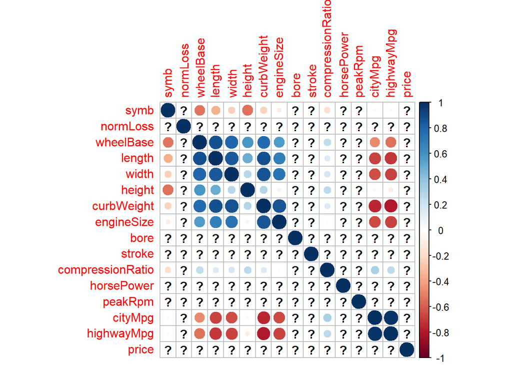

```r
#install.packages("corrplot")
library(corrplot)

numeric_data <- carIns[, sapply(carIns, is.numeric)]
cor_matrix <- cor(numeric_data)

corrplot(cor_matrix)
```

```r
#corrplot(cor_matrix, method = "spearman", type = "lower", tl.cex = 0.8, tl.col = "black", addcolor = "white", col = "RdBu", title = "Correlation Matrix")
```

**5. Load the data set USJudgeRatings1, from the datasets package, containing lawyers’ ratings of state judges in the US Superior Court regarding a set of attributes.**

1. Apply the function prcomp() to obtain the principal components. Inspect how each variable is obtained by the linear combination of each component.

```r
# Cargar el paquete "datasets" que contiene el conjunto de datos
library(datasets)
#USJudgeRatings<- read.csv("C:/Proyectos ML/Mineria/Hands_On_2/data/dataset-29460.csv")

# Cargar el conjunto de datos "USJudgeRatings"
data(USJudgeRatings)
# Obtener solo las columnas numéricas del conjunto de datos
numeric_columns <- USJudgeRatings[, sapply(USJudgeRatings, is.numeric)]

# Aplicar la función prcomp() para obtener los componentes principales
pca <- prcomp(numeric_columns)
# Inspeccionar los resultados
summary(pca)
```

```
## Importance of components:
##                           PC1    PC2     PC3     PC4     PC5    PC6     PC7
## Standard deviation     3.0299 0.9879 0.55470 0.46986 0.26398 0.1741 0.12895
## Proportion of Variance 0.8476 0.0901 0.02841 0.02038 0.00643 0.0028 0.00154
## Cumulative Proportion  0.8476 0.9377 0.96612 0.98650 0.99294 0.9957 0.99727
##                            PC8     PC9    PC10    PC11    PC12
## Standard deviation     0.10868 0.08724 0.07122 0.05571 0.04397
## Proportion of Variance 0.00109 0.00070 0.00047 0.00029 0.00018
## Cumulative Proportion  0.99836 0.99907 0.99953 0.99982 1.00000
```

2. Load the package ggbiplot and plot the two first components with the function ggbiplot(). You can label each point with the lawyer’s name by setting the labels parameter.

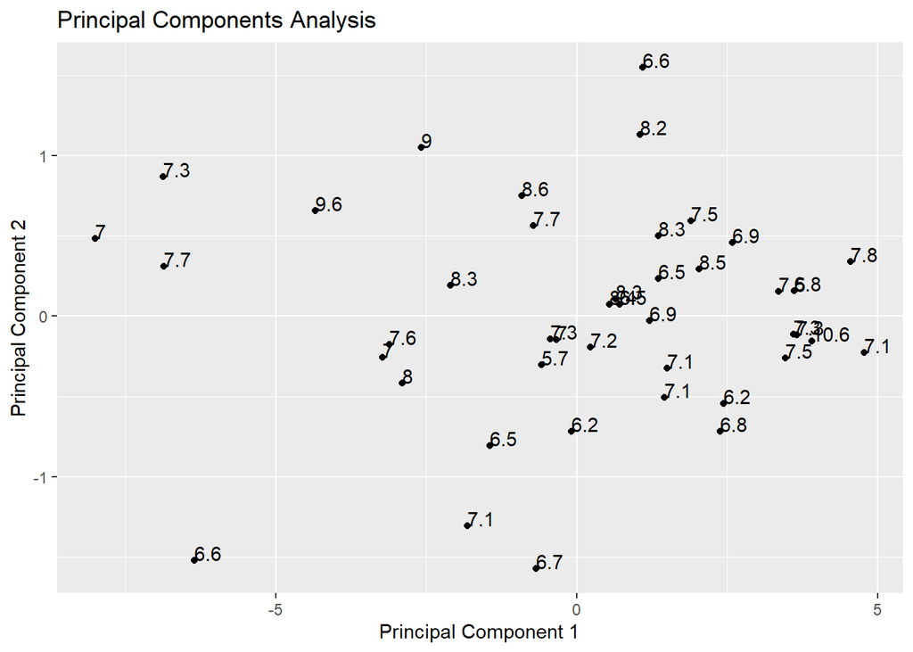

```r
library(datasets)
library(ggplot2)
# Load the USJudgeRatings dataset
data(USJudgeRatings)

# Apply PCA using prcomp()
#pca <- prcomp(USJudgeRatings[, 1:12], scale. = TRUE)
pca <- prcomp(USJudgeRatings[,-1],scale. = TRUE)

# Extract the first two principal components
pc1 <- pca$x[, 1]
pc2 <- pca$x[, 2]

# Create a data frame with the PC scores and judge names
df <- data.frame(pc1, pc2, Judge = USJudgeRatings$CONT)

# Create a scatter plot of the first two components
ggplot(df, aes(x = pc1, y = pc2, label = Judge)) +
  geom_point() +
  geom_text(hjust = 0, vjust = 0) +
  xlab("Principal Component 1") +
  ylab("Principal Component 2") +
  ggtitle("Principal Components Analysis")
```